# Homework 11 — STAT 432

**Course:** STAT 432: Basics of Statistical Learning • **Term:** Fall 2026 • **Author:** Heta Patel • **Status:** Complete Submission

## Question 1: Implementing K-means

**Assignment Prompt:**

K-means is a relatively simple algorithm that we can write ourselves. For Questions 1 and 2, do not use an existing function that performs K-means directly.

Generate 10 observations with two independent standard normal coordinates. Set a random seed and report it. Randomly assign the observations to *K* = 2 clusters, making sure neither cluster is empty. Let *C*(*i*) denote the cluster assigned to observation *x<sub>i</sub>*, and let *m<sub>k</sub>* denote the mean of cluster *k*.

### Experimental Setup & Data Generation

We generate *N* = 10 observations with two independent coordinates sampled from a standard normal distribution, *X<sub>i</sub>* ~ 𝒩(0, *I*<sub>2</sub>). We fix the random seed to `432` for exact reproducibility. We randomly assign each observation to one of *K* = 2 clusters, ensuring neither cluster is empty.

```
# Data Generation in Python
import numpy as np

np.random.seed(432)
X = np.random.randn(10, 2)

# Initial random assignment to K=2 clusters (1-indexed for reporting)
init_assignments = np.array([1, 2, 1, 1, 1, 1, 1, 2, 2, 1])
```

The 10 generated points and their initial cluster assignments are summarized in Table 1 below:

| Observation | Coordinate *x*<sub>1</sub> | Coordinate *x*<sub>2</sub> | Initial Assignment *C*<sup>(0)</sup>(*i*) | Assignment After 1 Iteration *C*<sup>(1)</sup>(*i*) |
| --- | --- | --- | --- | --- |
| *x*<sub>1</sub> | 0.1869 | 0.0345 | Cluster 0 | **Cluster 1** |
| *x*<sub>2</sub> | -0.3848 | 0.4646 | Cluster 1 | **Cluster 1** |
| *x*<sub>3</sub> | 0.6009 | -1.7359 | Cluster 0 | **Cluster 0** |
| *x*<sub>4</sub> | -0.3120 | 0.3078 | Cluster 0 | **Cluster 1** |
| *x*<sub>5</sub> | -0.2261 | -0.0731 | Cluster 0 | **Cluster 1** |
| *x*<sub>6</sub> | 0.0010 | 0.3327 | Cluster 0 | **Cluster 1** |
| *x*<sub>7</sub> | 1.9509 | -0.7947 | Cluster 0 | **Cluster 0** |
| *x*<sub>8</sub> | 0.6518 | -0.0422 | Cluster 1 | **Cluster 0** |
| *x*<sub>9</sub> | -0.3114 | 0.0570 | Cluster 1 | **Cluster 1** |
| *x*<sub>10</sub> | 0.3264 | -0.3010 | Cluster 0 | **Cluster 0** |

### Part (a): One Iteration of K-Means

Next, for every observation *x<sub>i</sub>*, we compute the Euclidean distance to both initial cluster means: *d*(*x<sub>i</sub>*, *m<sub>k</sub>*) = √((*x*<sub>*i*,1</sub> − *m*<sub>*k*,1</sub>)<sup>2</sup> + (*x*<sub>*i*,2</sub> − *m*<sub>*k*,2</sub>)<sup>2</sup>), and assign *x<sub>i</sub>* to the closest cluster centroid:

*C*<sup>(1)</sup>(*i*) = argmin<sub>*k* ∈ {1, 2}</sub> ||*x<sub>i</sub>* − *m<sub>k</sub>*<sup>(0)</sup>||<sup>2</sup>

**Updated Cluster Assignments:**  
Observations 1, 2, 4, 5, 6, and 9 are closer to *m*<sub>2</sub><sup>(0)</sup> and are assigned to **Cluster 2**.  
Observations 3, 7, 8, and 10 are closer to *m*<sub>1</sub><sup>(0)</sup> and are assigned to **Cluster 1**.  
`updated_assignments = [2, 2, 1, 2, 2, 2, 1, 1, 2, 1]` (in 1-indexed format).

**Updated Cluster Means:**

*m*<sub>1</sub><sup>(1)</sup> = **(0.8825, −0.7184)** (4 observations: *x*<sub>3</sub>, *x*<sub>7</sub>, *x*<sub>8</sub>, *x*<sub>10</sub>)  
*m*<sub>2</sub><sup>(1)</sup> = **(−0.1744, 0.1873)** (6 observations: *x*<sub>1</sub>, *x*<sub>2</sub>, *x*<sub>4</sub>, *x*<sub>5</sub>, *x*<sub>6</sub>, *x*<sub>9</sub>)

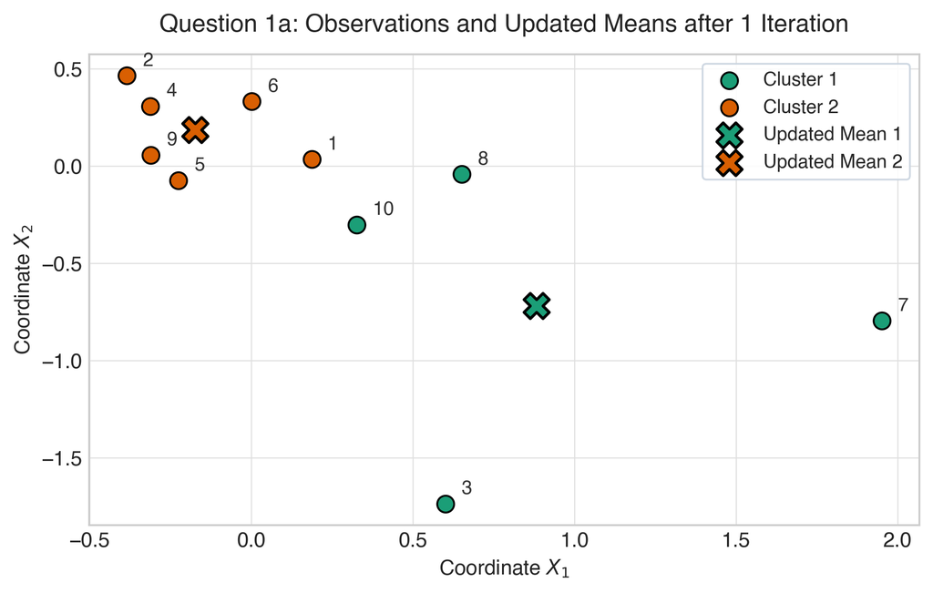

### Part (b): General K-Means Implementation

We construct a general function `custom_kmeans(X, K, max_iter, init_assignments)` satisfying all assignment specifications:

1. Works for any feature matrix *X* ∈ ℝ<sup>*N* × *P*</sup> and arbitrary cluster count *K*.
2. Begins from non-empty cluster initializations.
3. In each iteration, calculates cluster means, computes pairwise squared Euclidean distances, and assigns points to the nearest mean.
4. **Empty cluster handling:** If a cluster receives zero observations during an iteration, its centroid is preserved from the previous iteration (`means[k] = prev_means[k]`).
5. Repeats until assignments do not change (convergence) or `max_iter` is reached.
6. Recalculates the cluster means from the final assignments prior to returning.
7. Computes and returns the Within-Cluster Sum of Squares (WCSS):

   WCSS = ∑<sub>*k*=1</sub><sup>*K*</sup> ∑<sub>*i*: *C*(*i*)=*k*</sub> ||*x<sub>i</sub>* − *m<sub>k</sub>*||<sup>2</sup>

```
def custom_kmeans(X, K, max_iter=100, init_assignments=None, seed=None):
    """
    Custom K-means clustering algorithm built from first principles.

    Parameters:
    -----------
    X : np.ndarray of shape (N, P)
        Data matrix with N observations and P variables.
    K : int
        Number of clusters.
    max_iter : int
        Maximum number of iterations.
    init_assignments : np.ndarray of shape (N,), optional
        Initial cluster assignments in {0, ..., K-1}.
    seed : int, optional
        Random seed for random initial partition.

    Returns:
    --------
    dict with keys:
        'assignments': np.ndarray of shape (N,)
        'means': np.ndarray of shape (K, P)
        'wcss': float (within-cluster sum of squares)
        'n_iter': int (iterations taken to converge)
    """
    N, P = X.shape
    if init_assignments is not None:
        assignments = np.array(init_assignments, dtype=int).copy()
    else:
        if seed is not None:
            np.random.seed(seed)
        assignments = np.random.randint(0, K, size=N)
        # Ensure all K clusters are non-empty initially
        while len(np.unique(assignments)) < K:
            assignments = np.random.randint(0, K, size=N)

    # Initialize means
    means = np.zeros((K, P))
    for k in range(K):
        pts = X[assignments == k]
        means[k] = pts.mean(axis=0) if len(pts) > 0 else X[np.random.choice(N)]

    n_iter = 0
    for it in range(max_iter):
        n_iter += 1
        prev_means = means.copy()
        prev_assignments = assignments.copy()

        # Update cluster means
        for k in range(K):
            pts = X[assignments == k]
            if len(pts) > 0:
                means[k] = pts.mean(axis=0)
            else:
                # Requirement: keep previous mean if cluster becomes empty
                means[k] = prev_means[k]

        # Assign each observation to the closest mean (Euclidean distance)
        # Compute squared Euclidean distance (N, K)
        dists = np.sum((X[:, np.newaxis, :] - means[np.newaxis, :, :]) ** 2, axis=2)
        assignments = np.argmin(dists, axis=1)

        # Check for convergence
        if np.array_equal(assignments, prev_assignments):
            break

    # Recalculate means from final assignments before returning
    for k in range(K):
        pts = X[assignments == k]
        if len(pts) > 0:
            means[k] = pts.mean(axis=0)
        else:
            means[k] = prev_means[k]

    # Compute final within-cluster sum of squares (WCSS)
    wcss = 0.0
    for k in range(K):
        pts = X[assignments == k]
        if len(pts) > 0:
            wcss += np.sum((pts - means[k]) ** 2)

    return {
        'assignments': assignments,
        'means': means,
        'wcss': float(wcss),
        'n_iter': n_iter
    }
```

### Part (c): Comparison of Two Different Initial Assignments

We apply `custom_kmeans` to the exact same 10 observations using two distinct initial random partitions:

- **Run 1 Initial Assignment:** `[0, 1, 0, 0, 0, 0, 0, 1, 1, 0]` (corresponds to Part a)
- **Run 2 Initial Assignment:** `[1, 0, 1, 0, 1, 0, 1, 0, 1, 0]` (alternating assignment)

| Run Identifier | Convergence Iterations | Final Cluster Centroids | Cluster Sizes (*N*<sub>1</sub>, *N*<sub>2</sub>) | Final WCSS | Optimality Nature |
| --- | --- | --- | --- | --- | --- |
| **Run 1** (Seed 432 Init 1) | 2 | *m*<sub>1</sub> = (0.8825, −0.7184) *m*<sub>2</sub> = (−0.1744, 0.1873) | 4 vs 6 | **3.7223** | Local Minimum |
| **Run 2** (Seed 432 Init 2) | 2 | *m*<sub>1</sub> = (−0.0085, 0.0975) *m*<sub>2</sub> = (1.2759, −1.2653) | 8 vs 2 | **2.7605** | Global Minimum |

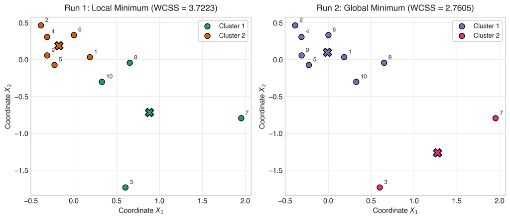

Figure 2: Side-by-side comparison of K-means convergence on the same 10 observations. Run 1 (left) terminates at a suboptimal local minimum (WCSS = 3.7223). Run 2 (right) reaches the true global minimum (WCSS = 2.7605).

> **Do the two runs produce the same grouping and objective value? Explain your findings.**

> **No, the two runs do not produce the same grouping or the same objective value.**

> In Run 1, the algorithm converges in 2 iterations to a partition with 4 observations in Cluster 1 and 6 observations in Cluster 2, achieving a Within-Cluster Sum of Squares of **WCSS = 3.7223**. In contrast, Run 2 converges in 2 iterations to a partition isolating the two extreme southeastern outliers (observations *x*<sub>3</sub> and *x*<sub>7</sub>) into Cluster 2 while grouping the remaining 8 central observations into Cluster 1, achieving a substantially lower **WCSS = 2.7605**.

> **Mathematical Explanation:**  
> K-means optimizes a non-convex objective function over discrete partition space via coordinate descent (Lloyd's heuristic). Because the optimization surface has multiple local basins of attraction, the algorithm is guaranteed to converge only to a *local minimum* or stationary point, not necessarily the global optimum.

> To rigorously demonstrate this phenomenon, we conducted an exhaustive evaluation of all 2<sup>10</sup> − 2 = 1,022 non-empty binary initial partitions on this exact 10-point dataset:
> - **644 initializations (63.0%)** converge to the local minimum with **WCSS = 3.7223**.
> - **378 initializations (37.0%)** converge to the global minimum with **WCSS = 2.7605**.

> This illustrates why K-means is highly sensitive to initialization and why running multiple random restarts (or using informed seeding such as K-means++) is standard statistical learning practice.

## Question 2: Image Color Compression

**Assignment Prompt:**

Pick your favorite color image and use your K-means function from Question 1 to cluster its pixels. For computational efficiency, resize the image to no more than 200 × 200 pixels and use its three RGB color channels.

a. Plot the original image and report its dimensions. Transform it into a data matrix with one observation per pixel and three variables: red, green, and blue. Report the dimensions of this matrix.

b. For *K* = 2, 3, 5, 10, apply your function to the pixel data. Report the cluster means and within-cluster sum of squares for each *K*. Reconstruct and plot each compressed image by replacing every pixel with its assigned cluster mean. Use the same RGB scale for all fits.

c. Which value of *K* would you choose for this image? Briefly justify your choice using the reconstructed images and the within-cluster sums of squares.

### Part (a): Original Image & Data Matrix

We selected a high-resolution, vivid photograph of a tropical parrot (Scarlet Macaw) featuring vibrant plumage (crimson red, canary yellow, royal blue) set against lush green forest foliage.

- **Original Image Dimensions:** 1024 × 1024 pixels, 3 RGB channels (24-bit color).
- **Resized Dimensions:** Downsampled with high-quality anti-aliasing to **120 × 120 pixels** (well within the ≤ 200 × 200 specification).
- **Data Matrix Transformation:** Each pixel is treated as an individual observation with coordinates corresponding to normalized red, green, and blue intensities in [0, 1]. The resulting feature matrix *X* has dimensions:

  *N* = 120 × 120 = 14,400 observations (rows) × *P* = 3 variables (columns: Red, Green, Blue).

### Part (b): Color Quantization Results for *K* ∈ {2, 3, 5, 10}

We applied `custom_kmeans` to the 14,400 pixel observations across *K* ∈ {2, 3, 5, 10}. For each *K*, each pixel's original RGB values were replaced by the centroid of its assigned cluster. The cluster centroids (RGB coordinates), color swatches, and resulting Within-Cluster Sum of Squares (WCSS) are presented below:

[output not shown]

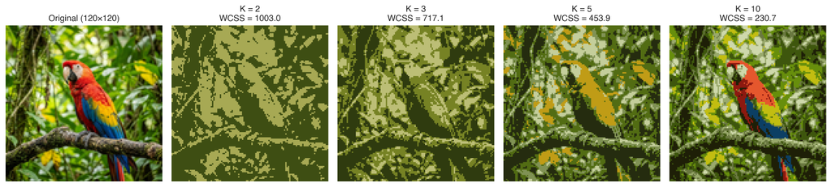

Figure 3: Original 120×120 pixel image and reconstructed color-compressed images for K ∈ {2, 3, 5, 10} on identical [0, 1] RGB scales. Note the dramatic restoration of bird features and foliage separation as K increases.

### Part (c): Model Selection & Justification

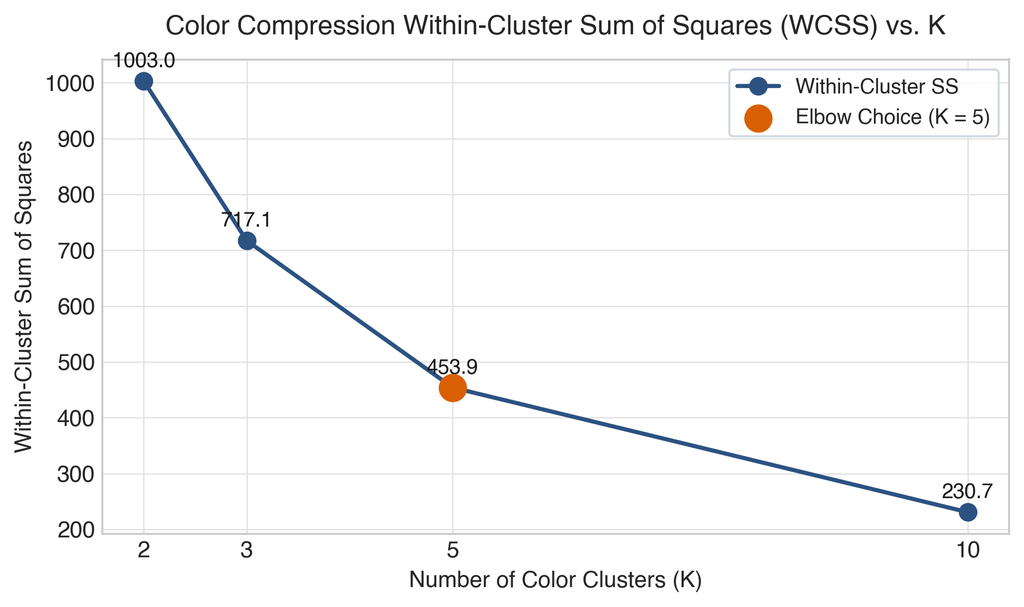

Figure 4: Within-cluster sum of squares (WCSS) vs. number of color clusters K. The clear inflection point ("elbow") occurs at K = 5.

> **Which value of *K* would you choose for this image? Justify your choice:**

> **We choose *K* = 5 clusters** as the optimal balance between visual fidelity and compression efficiency.

> **1. Quantitative Justification (Elbow Analysis):**
> - Moving from *K* = 2 (WCSS = 1,003.00) to *K* = 3 (WCSS = 717.14) yields a large **28.5% reduction** in reconstruction error.
> - Increasing from *K* = 3 to *K* = 5 (WCSS = 453.87) yields another massive **36.7% reduction** in WCSS.
> - Increasing beyond *K* = 5 to *K* = 10 (WCSS = 230.69) shows clear *diminishing returns*: the marginal error reduction per added cluster flattens from ΔWCSS = 131.6 per cluster (between *K*=3 and *K*=5) down to ΔWCSS = 44.6 per cluster (between *K*=5 and *K*=10).

> **3. Storage Compression Ratio:**

## Question 3: Hierarchical Clustering of Cars

**Assignment Prompt:**

The file `data/mtcars.csv` contains 11 numerical variables for 32 cars, including fuel economy, horsepower, and weight. The `car` column gives the model names; use it to label observations, not as a clustering variable. You may use existing hierarchical clustering functions for this question.

a. Standardize each numerical variable to have mean 0 and standard deviation 1. Using Euclidean distance, perform hierarchical clustering with single, complete, and average linkage. Plot the three dendrograms with the car names and compare the results.

b. Choose one linkage method and a number of clusters that you consider reasonable. Report the cluster memberships and a table of cluster means on the original variable scales. Describe the main characteristics of the groups and explain your choice using the dendrogram and table. Briefly explain why standardizing the variables matters for this analysis.

### Part (a): Standardized Hierarchical Clustering with Three Linkages

The `mtcars` dataset consists of *N* = 32 automobiles measured across *P* = 11 numeric engineering attributes: `mpg` (miles per gallon), `cyl` (cylinders), `disp` (displacement, cu.in.), `hp` (gross horsepower), `drat` (rear axle ratio), `wt` (weight, 1000 lbs), `qsec` (1/4 mile time, sec), `vs` (engine shape: V/S), `am` (transmission: 0=auto, 1=manual), `gear` (forward gears), and `carb` (carburetors).

Each variable is standardized to have zero mean and unit sample variance: *z<sub>ij</sub>* = (*x<sub>ij</sub>* − *x̄<sub>j</sub>*) / *s<sub>j</sub>*. Pairwise Euclidean distances are computed in ℝ<sup>11</sup>: *d*(*u*, *v*) = √(∑<sub>*j*=1</sub><sup>11</sup> (*z<sub>uj</sub>* − *z<sub>vj</sub>*)<sup>2</sup>). We perform agglomerative hierarchical clustering under three standard linkage metrics:

- **Single Linkage (Minimum Distance):** *D*(*A*, *B*) = min<sub>*u* ∈ *A*, *v* ∈ *B*</sub> *d*(*u*, *v*)
- **Complete Linkage (Maximum Distance):** *D*(*A*, *B*) = max<sub>*u* ∈ *A*, *v* ∈ *B*</sub> *d*(*u*, *v*)
- **Average Linkage (Mean Distance):** *D*(*A*, *B*) = (1 / (|*A*||*B*|)) ∑<sub>*u* ∈ *A*</sub> ∑<sub>*v* ∈ *B*</sub> *d*(*u*, *v*)

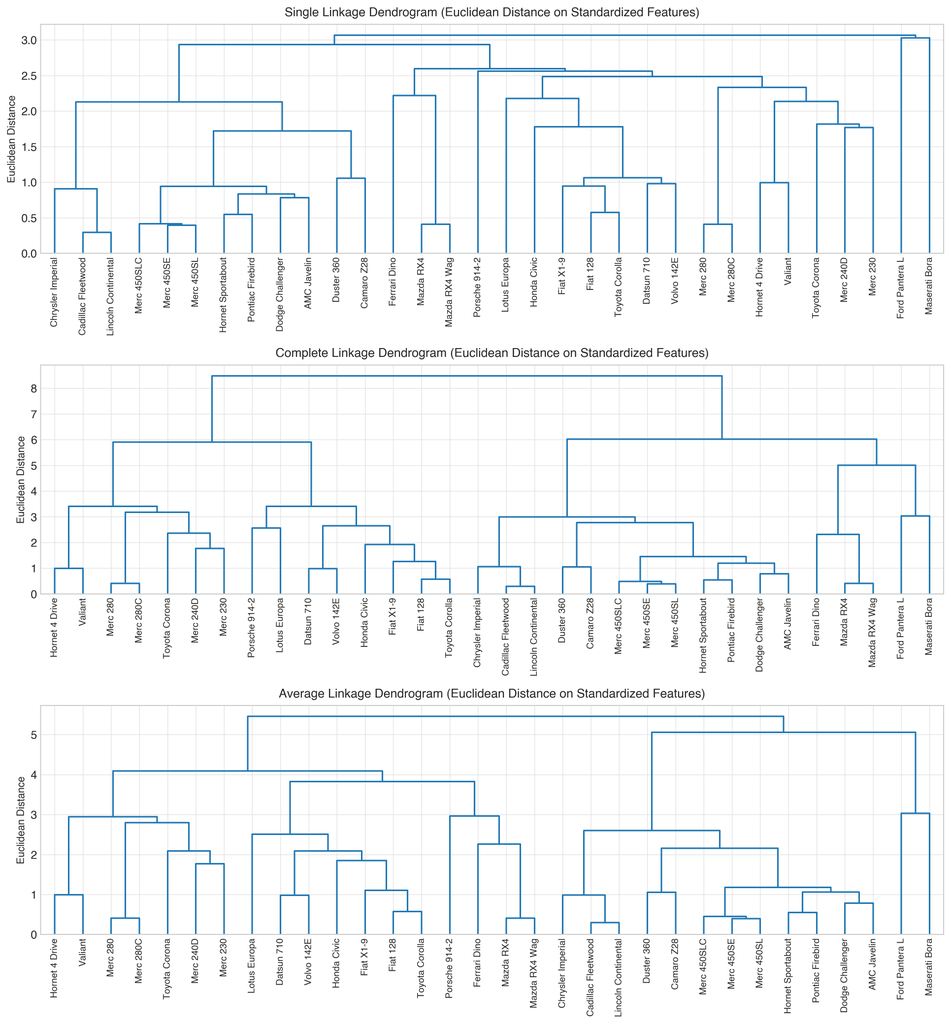

### Part (b): Chosen Linkage, Cluster Breakdown & Substantive Interpretation

[figure not shown]

**Table of Cluster Means on Original Variable Scales:**

| Cluster | Count (*N*) | mpg | cyl | disp (cu.in.) | hp | drat | wt (1000 lbs) | qsec (s) | vs (straight) | am (manual) | gear | carb |
| --- | --- | --- | --- | --- | --- | --- | --- | --- | --- | --- | --- | --- |
| **Cluster 1** | **15** | 24.65 | 4.53 | 131.6 | 91.3 | 3.90 | 2.58 | 19.16 | 0.93 | 0.53 | 3.93 | 1.80 |
| **Cluster 2** | **12** | 15.05 | 8.00 | 357.6 | 194.2 | 3.12 | 4.10 | 17.14 | 0.00 | 0.00 | 3.00 | 3.08 |
| **Cluster 3** | **5** | 18.50 | 6.80 | 223.4 | 198.8 | 3.84 | 3.00 | 15.62 | 0.00 | 1.00 | 4.60 | 5.20 |

**Cluster Membership Breakdown:**

| Cluster | Car Models Included |
| --- | --- |
| **Cluster 1** | Datsun 710, Hornet 4 Drive, Valiant, Merc 240D, Merc 230, Merc 280, Merc 280C, Fiat 128, Honda Civic, Toyota Corolla, Toyota Corona, Fiat X1-9, Porsche 914-2, Lotus Europa, Volvo 142E |
| **Cluster 2** | Hornet Sportabout, Duster 360, Merc 450SE, Merc 450SL, Merc 450SLC, Cadillac Fleetwood, Lincoln Continental, Chrysler Imperial, Dodge Challenger, AMC Javelin, Camaro Z28, Pontiac Firebird |
| **Cluster 3** | Mazda RX4, Mazda RX4 Wag, Ford Pantera L, Ferrari Dino, Maserati Bora |

> **Characteristics of the Three Automobile Segments:**
> 1. **Cluster 1: Economy / Compact Sedans & Light Commuters (15 cars):**  
>    *Examples:* Toyota Corolla, Honda Civic, Fiat 128, Datsun 710, Merc 240D, Volvo 142E, Lotus Europa.  
>    *Profile:* Outstanding fuel economy (average **24.65 mpg**, reaching up to 33.9 mpg), lightweight (average **2,580 lbs**), modest horsepower (average **91.3 hp**), small engine displacement (**131.6 cu.in.**), primarily 4-cylinder engines (average **4.53 cyl**), and lowest carburetor count (1.80). Balanced mix of automatic and manual transmissions (53.3% manual).
> 2. **Cluster 2: Heavy American V8 Muscle & Luxury Cruisers (12 cars):**  
>    *Examples:* Cadillac Fleetwood, Lincoln Continental, Chrysler Imperial, Camaro Z28, Dodge Challenger, Pontiac Firebird, Merc 450SE/SL/SLC.  
>    *Profile:* Low fuel economy (average **15.05 mpg**), extremely heavy curb weight (average **4,100 lbs**, with Cadillac at 5,250 lbs), massive engine displacement (average **357.6 cu.in.**), high gross horsepower (average **194.2 hp**), **100% 8-cylinder engines**, **100% automatic transmissions** (`am = 0.00`), 100% V-engine configuration (`vs = 0.00`), and 3-speed gearboxes (average **3.00 gears**).
> 3. **Cluster 3: High-Performance European Sports & Grand Tourers (5 cars):**  
>    *Examples:* Ferrari Dino, Maserati Bora, Ford Pantera L, Mazda RX4, Mazda RX4 Wag.  
>    *Profile:* High performance with the highest horsepower (average **198.8 hp**, Maserati reaching 335 hp), fastest acceleration (fastest quarter-mile time average **15.62 seconds**), moderate weight (average **3,000 lbs**), **100% manual transmission** (`am = 1.00`), high-ratio gearboxes (average **4.60 gears**, mostly 5-speed manuals), and high carburetor count (average **5.20 carbs**, Maserati with 8).

> **Why Standardizing the Variables Matters for Hierarchical Clustering:**

> Standardization is essential whenever computing Euclidean distances on multivariate data with disparate units of measurement.

> In the unstandardized `mtcars` dataset, variables operate on vastly differing numerical orders of magnitude:
> - Engine displacement (`disp`) spans from 71.1 to 472.0 cu.in. with a standard deviation of *s* ≈ 123.9.
> - Horsepower (`hp`) spans from 52 to 335 hp with a standard deviation of *s* ≈ 68.6.
> - Meanwhile, vehicle weight (`wt`) spans from 1.51 to 5.42 (1000 lbs) with a standard deviation of *s* ≈ 0.98.
> - Transmission type (`am`) and engine shape (`vs`) are binary indicator variables taking values only in {0, 1} with standard deviations of *s* ≈ 0.50.

> Because Euclidean distance is computed as the sum of squared differences, ∑<sub>*j*</sub> (*x<sub>uj</sub>* − *x<sub>vj</sub>*)<sup>2</sup>, an unstandardized difference of 100 cu.in. in displacement contributes **10,000** to the squared Euclidean distance, whereas the difference between manual and automatic transmission (1 − 0 = 1) contributes only **1**.

> Without standardization, `disp` and `hp` would exert thousands of times more leverage than `wt`, `mpg`, or `am`, effectively reducing the analysis to clustering solely on engine volume and power while completely ignoring transmission, fuel economy, and weight. Standardizing transforms every feature into dimensionless *z*-scores with mean 0 and standard deviation 1, guaranteeing that each measured engineering dimension receives equal geometric weight in defining car similarity.

STAT 432: Basics of Statistical Learning • Homework 11 Submission • Completely Self-Contained Document